# Assignment 1

Cheryl Gu cgu

# An Introduction to the exposome: exposome-wide association in body mass index and fasting glucose

Please check Canvas for the due date of this assignment.

**Start early.** This is a challenging assignment! Each student must hand in their code and answers separately. This assignment is 20% of your grade. We cannot accept late assignments.

Submit your answers as a knitted .html file: select the Knit drop down at the top of the window. Once converted to .html, select the file in the file browser, click the More drop down, and select Export.

```r
library(tidyverse)
```

## Background:

Body mass index and glucose are phenotypes that are known to be risk factors for Type 2 Diabetes (T2D). Genetic factors are associated with body mass index and glucose. However, environmental exposure factors associated to fasting glucose and/or body mass index may also play a role in T2D, given the rapid rise of both body mass index and diabetes in the last 20 years (https://www.cdc.gov/diabetes/statistics/slides/long_term_trends.pdf).

For example, it is hypothesized that “poor” diets or sugar consumption or even pollutants may influence body mass index or fasting glucose. However, these factors do not predict the phenotypes of body mass index or fasting glucose completely. In this assignment you will complement these associations in T2D, linking new potential environmental exposures in T2D phenotypes. Specifically, we will execute a data-driven search for environmental exposures correlated with body mass index and fasting glucose, called ‘environment-wide association studies’ or, alternatively, ‘exposome-wide association studies’ (ExWASs), similar to how investigators correlate individual SNPs with disease in GWAS.

### Description of Data and Readings:

Please skim [Patel et al 2010](https://www.ncbi.nlm.nih.gov/pmc/articles/PMC2873978/). Optionally, check out this essay on the topic: [Chung at al In press](https://academic.oup.com/exposome/advance-article/doi/10.1093/exposome/osae001/7574628)

```r
load('./assignment1.Rdata')
```

This .Rdata file contains 5 data.frames and an array named the following:

- ExposureDescription:the dictionary of exposure variables in the training and testing datasets
- ExposureList: a list of biomarkers of environmental exposures to test against BMI and glucose.
- NHData.train: the training dataset from the NHANES 1999-2000 and 2001-2002 surveys
- NHData.test: the testing dataset from the NHANES 2003-2004 and 2005-2006 surveys
- demographicVariables: a dictionary of demographic variables in the training and testing datasets.

These data were derived from the National Health and Nutrition Examination Survey (NHANES), a survey on a representative sample of the United States population, undertaken by the US Centers for Disease Control and Prevention (see here: https://www.cdc.gov/nchs/nhanes/. Specifically, we downloaded the data from the NHANES web site and stitched them together to create the data.frame objects above. For more information, please see [Patel CJ, et al 2016, Nature Scientific Data](http://www.nature.com/articles/sdata201696).

# A short tutorial on analysis of survey data

The NHANES participants are representative of the United States population. A challenge in making a dataset representative is ensuring all types of individuals are sampled that reflect the diversity of the US at the lowest possible cost. Simply calling a finite number of people up randomly is not going to achieve representativeness. The US CDC and National Centers for Health Statistics (NCHS) are able to achieve representativeness by sampling specific facets of the population at higher probabilities than would be observed if one was to randomly sample the population. Second, NCHS samples people from specific parts of the population (e.g., 15 counties a year) to save time and money (it is easier to survey people in a neighborhood than randomly all over the US).

In fact, most data that you will find from the US CDC or international epidemiological surveys, use a special sampling technique called “survey sampling”. You can learn more about the CDC and the NCHS sampling procedure here: https://wwwn.cdc.gov/Nchs/Nhanes/AnalyticGuidelines.aspx

What does this mean for us? We cannot use the common tools in R to do modeling if we desire to produce “valid” effect sizes, associations/correlations, and pvalues. Why? Because individuals are not sampled randomly, they exhibit some inherent correlation with others (e.g., individuals sampled from the same town, for example). Therefore, this will influence the standard errors and averages of the correlations and therefore also influence the inference (pvalues for correlation).

How do we address this? We simply use a package, aptly called ‘survey’, to take into account the unequal survey-weighted design of the NHANES population. The two main functions you will use in this assignment to achieve this includes ‘svydesign’ and ‘svyglm’ (survey-weighted general linear modeling, which can do linear, logistic, and other types of regressions). Here is how you use them using the NHdata.train data.frame.

First, we need to load the ‘survey’ package:

```r
library(survey)
```

Next, we need to tell R that we have a survey-weighted data we need to analyze. This is done through the ‘svydesign’ function from the survey library, for example for the training data, NHData.train:

```r
dsn <- svydesign(ids=~SDMVPSU, strata=~SDMVSTRA, weights=~WTMEC2YR, nest=T, data=NHData.train)
```

This tells R that we have a survey-weighted sample (denoted by weights in the function above). The weights signify how much an individual should be considered in the model and is a function of their prevalence in the population. For example, individuals with higher weights are less prevalent in the population. In contrast, in a simple random sample, the weights would be equal for every individual. Second, the ids and strata parameters tell R where an individual was sampled. ‘Strata’ are units (such as zipcodes) that are sampled within ‘primary sampling units’ (or PSUs, SDMVPSU) such as a county. Individuals within strata are more correlated with one another than individuals that live in different strata. Therefore, these similarities within sampling strata must be taken into account when estimating correlations.

We can run regression models using the ‘svyglm’ function. For example, suppose I wanted to regress Body Mass Index (coded as BMXBMI in the data.frame) on age (coded as RIDAGEYR), we can use the ‘svyglm’ function (INSTEAD of the regular ‘lm’ function):

```r
mod <-svyglm(BMXBMI ~ RIDAGEYR, dsn)
summary(mod)
```

```
##
## Call:
## svyglm(formula = BMXBMI ~ RIDAGEYR, design = dsn)
##
## Survey design:
## svydesign(ids = ~SDMVPSU, strata = ~SDMVSTRA, weights = ~WTMEC2YR,
##     nest = T, data = NHData.train)
##
## Coefficients:
##              Estimate Std. Error t value Pr(>|t|)
## (Intercept) 20.662323   0.144659  142.84   <2e-16 ***
## RIDAGEYR     0.145503   0.003441   42.29   <2e-16 ***
## ---
## Signif. codes:  0 '***' 0.001 '**' 0.01 '*' 0.05 '.' 0.1 ' ' 1
##
## (Dispersion parameter for gaussian family taken to be 45.1212)
##
## Number of Fisher Scoring iterations: 2
```

Observe that the estimates (and pvalues) will be different when using the ‘lm’ function (give it a shot):

```r
mod2 <- lm(BMXBMI ~ RIDAGEYR, data=NHData.train)
summary(mod2)
```

```
##
## Call:
## lm(formula = BMXBMI ~ RIDAGEYR, data = NHData.train)
##
## Residuals:
##     Min      1Q  Median      3Q     Max
## -18.868  -4.396  -1.225   3.070  40.347
##
## Coefficients:
##              Estimate Std. Error t value Pr(>|t|)
## (Intercept) 20.428038   0.077834  262.46   <2e-16 ***
## RIDAGEYR     0.141623   0.002013   70.37   <2e-16 ***
## ---
## Signif. codes:  0 '***' 0.001 '**' 0.01 '*' 0.05 '.' 0.1 ' ' 1
##
## Residual standard error: 6.21 on 17470 degrees of freedom
##   (3532 observations deleted due to missingness)
## Multiple R-squared:  0.2208, Adjusted R-squared:  0.2208
## F-statistic:  4951 on 1 and 17470 DF,  p-value: < 2.2e-16
```

In this assignment, we will use the survey package and ‘svydesign’ and ‘svyglm’ functions to run your association tests. These are good functions to know when analyzing data from the public domain.

Answer the questions that are numbered in the space below that says “your answer here”. Supply R code when required by using the back ticks. For example:

## Sample Questions (and Answers):

1. What is the meaning of life?

The meaning of life is 42.

2. What is e to the power of 3?

```r
exp(3)
```

```
## [1] 20.08554
```

# A. Background Questions

1. How are the phenotypes (glucose and BMI) measured in participants of the NHANES? (1)
- The glucose, meaured in the form of “Fasting subsample weights” for participants aged 12 years and over who were examined in a morning session and fasted 8–23 hours.
- BMI, measured in the form of Self-reported height and weight for participants in age group “40-59” and “60 and over”.

(reference: https://wwwn.cdc.gov/Nchs/Nhanes/AnalyticGuidelines.aspx#sample-design)

2. What does representative mean with respect to NHANES? How is it different than the [Framingham Heart Study](https://www.nih.gov/sites/default/files/about-nih/impact/framingham-heart-study.pdf)? (2)
- In the context of NHANES, “representative” means that the participants in the survey are selected that represent the entire U.S nation, which is called nationally representative.
- NHANES is designed to be representative of the U.S. population and it is a cross-sectional study. However, Framingham Heart Study is a longitudinal cohort study is designed to only follow a group of individuals from a study site over time to determine the natural history of heart diseases.
3. These phenotypes (glucose and BMI) are related to type 2 diabetes. (a) Draw the E, G, P, and D diagram and annotate what you are investigating in your anticipated NHANES EWASs. (b) What does body mass index measure? What does fasting glucose measures? Why are they important in type 2 diabetes? (2)

a:

- Phenotype(s): body mass index (BMI), glucose
- Exposure(s): EWAS Environment Factors
- Disease(s): Tyoe 2 disbetes

b:

- Body Mass Index (BMI) measures a person’s weight in kilograms divided by the square of height in meters. BMI is used to indicate the obesity and body fat of a person. Fasting glucose measures the glucose level in the blood. Both BMI and fasting glucose are important in the context of type 2 diabetes because they can indicate the increased risk for type 2 diabetes, higher BMI and higher FBG would have higher risk of developing T2D.
4. How are the environmental exposures measured in the NHANES? Choose a few examples (up to 5) of different types of biomarkers of environmental exposures from the ExposureList array and query the NHANES website for the assay description of the biomarker. (2)
- your answer here

All the biospecimens collected in the MEC included blood, hair, nasal swab, oral rinse, urine, and vaginal swab. - Acrylamide, collected from whole blood. - Albumin, collected from urine. - Apolipoprotein (B), collected from serum. - Arsenic, collected from urine.

### Let’s explore the phenotypes, body mass index (BMXBMI) and fasting glucose (LBXGLU) with respect to demographic characteristics of your population in the training dataset (NHData.train)

5. How many individuals are there with BMI values? Draw a histogram of BMI and describe the mean and median. Is the distribution “skewed” or biased toward a certain direction on the x axis? (1)
- your answer here (with R code). Remember, use the NHData.train cohort.

```r
num_bmi <- sum(!is.na(NHData.train$BMXBMI))

mean_bmi <- mean(NHData.train$BMXBMI, na.rm = TRUE)

median_bmi <- median(NHData.train$BMXBMI, na.rm = TRUE)

# Print the results
cat("Number of individuals with BMI values:", num_bmi, "\n")
```

```
## Number of individuals with BMI values: 17472
```

```r
cat("Mean of BMI:", mean_bmi, "\n")
```

```
## Mean of BMI: 24.79468
```

```r
cat("Median of BMI:", median_bmi, "\n")
```

```
## Median of BMI: 24.1
```

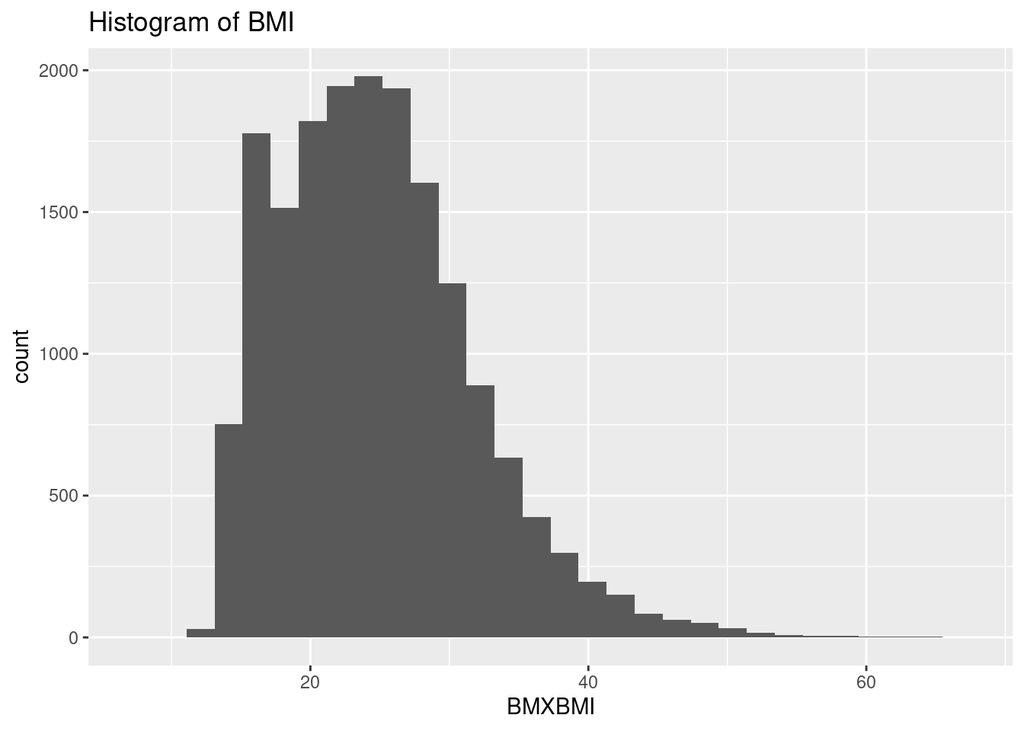

```r
ggplot(NHData.train, aes(x = BMXBMI)) +
  geom_histogram() +
  labs(title = "Histogram of BMI")
```

```r
cat("From the histogram, we oberserve that the distribution is skewed/biased to the right direction on the x-axis.")
```

```
## From the histogram, we oberserve that the distribution is skewed/biased to the right direction on the x-axis.
```

6. Plot BMI vs age. (1)
- your answer here

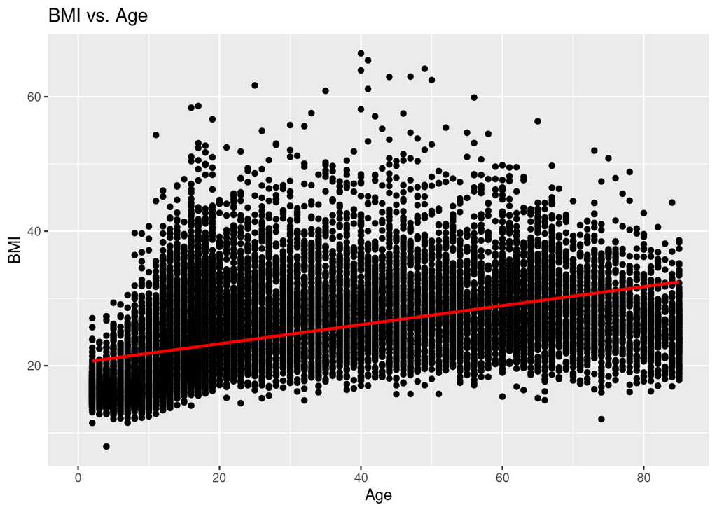

```r
ggplot(NHData.train, aes(x = RIDAGEYR, y = BMXBMI)) +
  geom_point() +
  geom_smooth(method = "lm", color = "red") +
  labs(title = "BMI vs. Age",
       x = "Age", y = "BMI")
```

7. Plot a boxplot of BMI versus sex. (1)
- your answer here

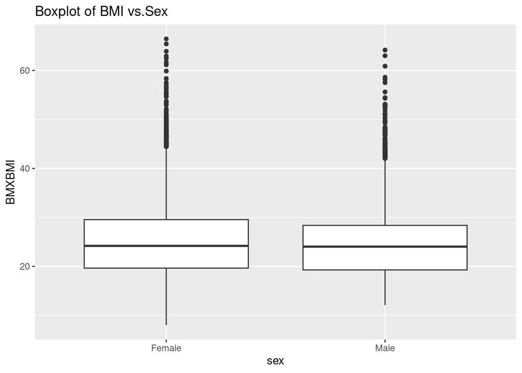

```r
# Ensure the dataset is loaded
NHData.train <- NHData.train %>%
  mutate(sex = case_when(female == '1' ~ 'Female',
                         female == '0' ~ 'Male' ))
ggplot(NHData.train, aes(x=sex, y=BMXBMI)) +
  geom_boxplot() +
  labs(title = "Boxplot of BMI vs.Sex")
```

8. Plot a boxplot of BMI versus race/ethnicity. (2)
- your answer here

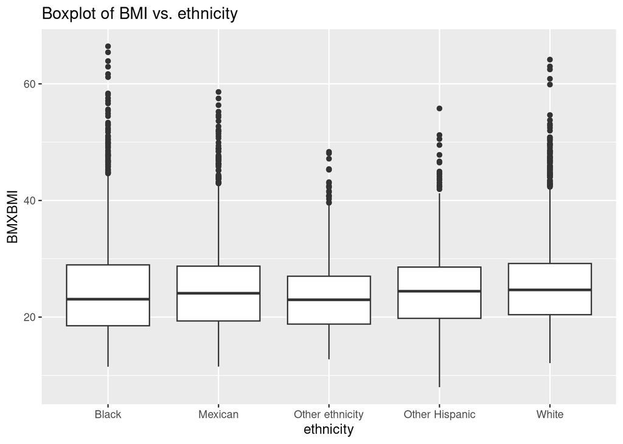

```r
NHData.train <- NHData.train %>%
  mutate(ethnicity = case_when(
    black == 1 ~ "Black",
    white == 1 ~ "White",
    other_hispanic == 1 ~ "Other Hispanic",
    other_eth == 1 ~ "Other ethnicity",
    mexican == 1 ~ "Mexican",
    TRUE ~ "Unknown"
  ))

ggplot(NHData.train, aes(x=ethnicity, y=BMXBMI)) +
  geom_boxplot() +
  labs(title = "Boxplot of BMI vs. ethnicity")
```

9. Plot BMI versus an indicator of socioecononomic status, the income to poverty ratio (INDFMPIR). The income-to-poverty ratio is a the household income divided by the household poverty level for a given survey year. Therefore a Income-to-poverty ratio of 1 means the individual has household income equal to the poverty level. (1)
- your answer here

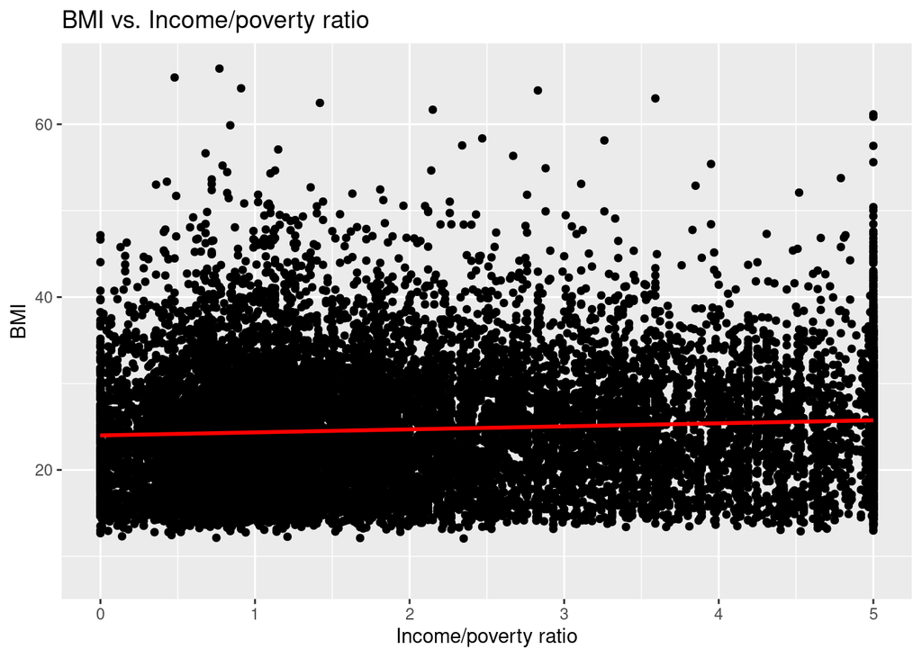

```r
ggplot(NHData.train, aes(x = INDFMPIR, y = BMXBMI)) +
  geom_point() +
  geom_smooth(method = "lm", color = "red") +
  labs(title = "BMI vs. Income/poverty ratio",
       x = "Income/poverty ratio", y = "BMI")
```

We need to use a survey-weighted generalized linear model to test the association and significance.

```r
NHData.train$ethnicity <- factor(NHData.train$ethnicity, levels = c("White", "Black", "Hispanic", "Other ethnicity", "Mexican", "Other Hispanic"))
dsn <- svydesign(ids=~SDMVPSU, strata=~SDMVSTRA, weights=~WTMEC2YR, nest=T, data=NHData.train)
mod2 <-svyglm(BMXBMI ~ RIDAGEYR + female + factor(ethnicity) + INDFMPIR, dsn)
summary(mod2)
```

```
##
## Call:
## svyglm(formula = BMXBMI ~ RIDAGEYR + female + factor(ethnicity) +
##     INDFMPIR, design = dsn)
##
## Survey design:
## svydesign(ids = ~SDMVPSU, strata = ~SDMVSTRA, weights = ~WTMEC2YR,
##     nest = T, data = NHData.train)
##
## Coefficients:
##                                   Estimate Std. Error t value Pr(>|t|)
## (Intercept)                      20.217088   0.245206  82.449  < 2e-16 ***
## RIDAGEYR                          0.152421   0.003439  44.325  < 2e-16 ***
## female                            0.209020   0.132947   1.572    0.130
## factor(ethnicity)Black            1.560491   0.180950   8.624 1.66e-08 ***
## factor(ethnicity)Other ethnicity -0.012941   0.612393  -0.021    0.983
## factor(ethnicity)Mexican          0.992781   0.190223   5.219 3.10e-05 ***
## factor(ethnicity)Other Hispanic   0.553229   0.281339   1.966    0.062 .
## INDFMPIR                         -0.061980   0.056904  -1.089    0.288
## ---
## Signif. codes:  0 '***' 0.001 '**' 0.01 '*' 0.05 '.' 0.1 ' ' 1
##
## (Dispersion parameter for gaussian family taken to be 44.90787)
##
## Number of Fisher Scoring iterations: 2
```

### Using the model you described in 11, report the following:

We observe that Non-Hispanic Blacks have an average BMI 1.56 units higher than Whites, Mexican Americans have an average BMI 0.99 units higher than Whites, Other Hispanic have an average BMI 0.55 units higher than Whites, Other ethnicity have an average BMI 0.013 lower than Whites, while holding all other variables constant. Given the p-value for only Black and Mexican is lower than the thershold 0.05,we can only reject the null hypothesis that there is no relationship between age and these two ethnicities. Other two cannot reject the null as their p-value greater than 0.05. The result implies that the differences in BMI between Black and Whites, and between Mexican and Whites, are statistically significant. The differences in BMI between other Hispanic and Whites , and between other ethnicity and Whites are not statisticallt significant.

15. Repeat Q11 for fasting glucose (LBXGLU), developing a multivariate linear regression model to associate fasting glucose with age, sex, race, and income-poverty ratio. (3)
- your answer here

```r
dsn <- svydesign(ids=~SDMVPSU, strata=~SDMVSTRA, weights=~WTMEC2YR, nest=T, data=NHData.train)
mod3 <-svyglm(LBXGLU ~ RIDAGEYR + female + factor(ethnicity) + INDFMPIR, dsn)
summary(mod3)
```

```
##
## Call:
## svyglm(formula = LBXGLU ~ RIDAGEYR + female + factor(ethnicity) +
##     INDFMPIR, design = dsn)
##
## Survey design:
## svydesign(ids = ~SDMVPSU, strata = ~SDMVSTRA, weights = ~WTMEC2YR,
##     nest = T, data = NHData.train)
##
## Coefficients:
##                                  Estimate Std. Error t value Pr(>|t|)
## (Intercept)                       87.8945     1.0508  83.648  < 2e-16 ***
## RIDAGEYR                           0.4186     0.0291  14.388 1.13e-12 ***
## female                            -5.5616     0.8217  -6.768 8.41e-07 ***
## factor(ethnicity)Black             0.1312     1.4520   0.090  0.92884
## factor(ethnicity)Other ethnicity   3.0543     3.2390   0.943  0.35594
## factor(ethnicity)Mexican           3.4764     0.9499   3.660  0.00138 **
## factor(ethnicity)Other Hispanic    3.9009     2.8895   1.350  0.19073
## INDFMPIR                          -0.9295     0.2844  -3.268  0.00352 **
## ---
## Signif. codes:  0 '***' 0.001 '**' 0.01 '*' 0.05 '.' 0.1 ' ' 1
##
## (Dispersion parameter for gaussian family taken to be 1024.717)
##
## Number of Fisher Scoring iterations: 2
```

### We will explore one biomarker of exposure: serum Lead (LBXBPB).

16. Plot a histogram of serum lead (LBXBPB) and qualitatively describe the “shape” of the distribution - what does it look like? Is centered or skewed in a direction? (1)
- your answer here

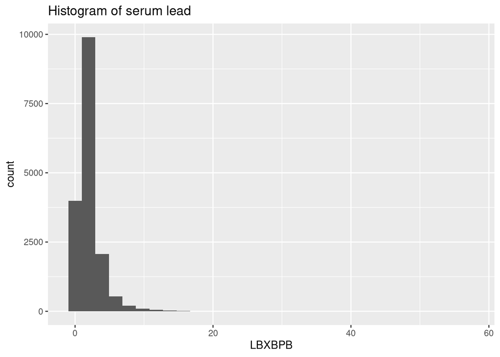

```r
ggplot(NHData.train, aes(x = LBXBPB)) +
  geom_histogram() +
  labs(title = "Histogram of serum lead")
```

The shape of serum lead histogram is skewed to the right direction of x-axis.

Investigators attempt to make this distribution more “normal” or symmetrically centered around a value by applying a “transformation” to make the linear associations easier to interpret. Since the lead levels seem to have an exponential-like decay a log-based transformation is used. Lets take a look at the log base e of lead levels:

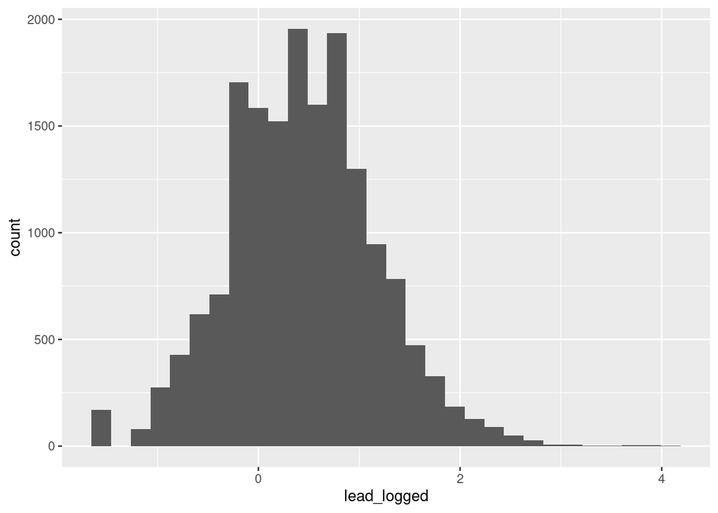

```r
NHData.train <- NHData.train %>% mutate(lead_logged = log(LBXBPB+ .001)) # add 0.001 for values that are 0
p <- ggplot(NHData.train, aes(lead_logged))
p <- p + geom_histogram()
p
```

### Using a multivariate linear regression model, estimate the following:

17. Execute a multivariate linear regression model to associate log(blood lead levels [plus .001, a small constant]) with age, sex, race, and income-poverty ratio, again in the training cohort (NHData.train) (3)
- your answer here

```r
dsn <- svydesign(ids=~SDMVPSU, strata=~SDMVSTRA, weights=~WTMEC2YR, nest=T, data=NHData.train)
mod4 <-svyglm(lead_logged ~ RIDAGEYR + female + factor(ethnicity) + INDFMPIR, dsn)
summary(mod4)
```

```
##
## Call:
## svyglm(formula = lead_logged ~ RIDAGEYR + female + factor(ethnicity) +
##     INDFMPIR, design = dsn)
##
## Survey design:
## svydesign(ids = ~SDMVPSU, strata = ~SDMVSTRA, weights = ~WTMEC2YR,
##     nest = T, data = NHData.train)
##
## Coefficients:
##                                    Estimate Std. Error t value Pr(>|t|)
## (Intercept)                       0.4019785  0.0350688  11.463 9.53e-11 ***
## RIDAGEYR                          0.0109253  0.0005453  20.035 1.28e-15 ***
## female                           -0.4316016  0.0127236 -33.921  < 2e-16 ***
## factor(ethnicity)Black            0.1718230  0.0224377   7.658 1.21e-07 ***
## factor(ethnicity)Other ethnicity -0.0401062  0.0386275  -1.038  0.31042
## factor(ethnicity)Mexican          0.1010466  0.0355791   2.840  0.00953 **
## factor(ethnicity)Other Hispanic   0.0003425  0.0475020   0.007  0.99431
## INDFMPIR                         -0.0648098  0.0054698 -11.849 5.07e-11 ***
## ---
## Signif. codes:  0 '***' 0.001 '**' 0.01 '*' 0.05 '.' 0.1 ' ' 1
##
## (Dispersion parameter for gaussian family taken to be 0.4047992)
##
## Number of Fisher Scoring iterations: 2
```

18. Could demographic variables be confounders in a test of association between Lead and BMI or glucose? Why or why not? (2)
- your answer here Demographic variables could be confounders in a test of association between Lead, BMI or glucose. Since we can observe statisticaly significant differences from age, sex, ethnicity variables, when testing associations between lead levels and BMI or glucose levels.

## B. Executing environment-wide associations

### Logging and scaling exposure variables

#### Logging variables

As above, to handle the right skew of exposure biomarkers, the measurements are log transformed. We add a constant (0.001). If we have a model such as the following:

```r
mod <- svyglm(LBXGLU ~ log(LBXBPB + .001), dsn)
summary(mod)
```

```
##
## Call:
## svyglm(formula = LBXGLU ~ log(LBXBPB + 0.001), design = dsn)
##
## Survey design:
## svydesign(ids = ~SDMVPSU, strata = ~SDMVSTRA, weights = ~WTMEC2YR,
##     nest = T, data = NHData.train)
##
## Coefficients:
##                     Estimate Std. Error t value Pr(>|t|)
## (Intercept)          98.2936     0.6279 156.535  < 2e-16 ***
## log(LBXBPB + 0.001)   4.3218     0.6638   6.511 4.68e-07 ***
## ---
## Signif. codes:  0 '***' 0.001 '**' 0.01 '*' 0.05 '.' 0.1 ' ' 1
##
## (Dispersion parameter for gaussian family taken to be 1107.804)
##
## Number of Fisher Scoring iterations: 2
```

How would you interpret the coefficient? Answer: for a 1 unit change in the log10(exposure), you have a 10 unit increase (9.95) in fasting glucose mg/dL.

Another way to interpret this is in terms of (percentages)[https://stats.oarc.ucla.edu/sas/faq/how-can-i-interpret-log-transformed-variables-in-terms-of-percent-change-in-linear-regression/]: a 1% change in the lead levels is associated with a 0.04 mg/dL (=4.32/100) higher serum glucose level. However this is association is not independent of potential confounding variables.

#### Scaling variables

Different variables have different units (e.g., mg/dL for lead levels). When we execute EWAS, we wish for every association to be comparable, or on the same units. Therefore, we need to “scale” the exposure variables to be on the same unit for each variable. One intuitive way to scale is to make all variables on the unit of standard deviation of that variable (e.g., sd(exposure)), dividing each measurement for each individual by the standard deviation of the population after subtracting the mean (centering the distribution at “0”). In code, to standardize or scale lead levels (after logging):

```r
NHData.train <- NHData.train %>% mutate(lead_standardized = scale(log(LBXBPB+.001))) # Ways to standardize or "scale" LBXBPB

NHData.train %>% summarize(m1= mean(lead_standardized, na.rm=T), m2 = mean(log(LBXBPB + .001), na.rm=T), s1 = sd(lead_standardized, na.rm = T), s2=sd(log(LBXBPB + .001), na.rm=T)) ## m1 should be 0, s1 should be equal to 1
```

```
##             m1        m2 s1        s2
## 1 2.872113e-17 0.4598617  1 0.7132666
```

### Doing EWAS

Now we will test each of the exposures in ExposureList for linear association with a quantitative or continuous trait in the training and testing datasets separately.

The script should input a the training or testing datasets and output a tibble that contains the exposure ID (e.g., LBXBPB),exposure name, phenotype name,estimate,standard error, pvalue, an false discovery rate (FDR).

Your code should execute associations that associate between each exposure in ExposureList and the phenotype (e.g., BMI). The association should quantify how much the phenotype changes for a 1 standard deviation change in the logarithm base 10 of the exposure value (e.g., scale(log(exposure + 0.001))).

Because some of the exposure variables contain 0 values we need to add a constant before doing a log transformation. Choosing a constant is a matter of hot debate. For the sake of the exercise, use a small constant equal to 0.001. The dependent variable is the phenotype, and the independent variable is an exposure. Include age, sex, race/ethnicity, and income/poverty ratio (INDFMPIR) as covariates.

Execute the following:

1. EWAS on 1 standard deviation change of Body Mass Index (BMXBMI) in the training and testing datasets separately. Use ‘svyglm’ as the regression approach of choice (see function below). (5)

```r
# here is an (optional) function you can use to take in phenotype and exposure variables as "string" input to a linear regression:

### function to do a pairwise association between a phenotype and exposure
association <- function(phenotype="BMXBMI", exposure="LBXBCD", covariates=c("male", "RIDAGEYR"), dsn) {
  # phenotype: a string that is a phenotype name (e.g., "BMXBMI")
  # exposure: a string this is a exposure name (e.g., "LBXBCD")
  # covariates: an array of covariate variables
  # dsn: the survey design object
  covariate_string <- paste(covariates, collapse="+")
  mod_string <- sprintf('scale(%s) ~ scale(log(%s + .001)) + %s', phenotype, exposure, covariate_string)
  # the above formats formula as a string
  mod <- svyglm(as.formula(mod_string), dsn)
  return(mod)
}

# run an association between BMI and Blood cadmium, adjusting for male sex and age in years
assoc_test_model <- association("BMXBMI", "LBXBCD", dsn=dsn)
summary(assoc_test_model)
```

```
##
## Call:
## svyglm(formula = as.formula(mod_string), design = dsn)
##
## Survey design:
## svydesign(ids = ~SDMVPSU, strata = ~SDMVSTRA, weights = ~WTMEC2YR,
##     nest = T, data = NHData.train)
##
## Coefficients:
##                              Estimate Std. Error t value Pr(>|t|)
## (Intercept)                -0.5107741  0.0285754 -17.875 3.99e-16 ***
## scale(log(LBXBCD + 0.001)) -0.0134758  0.0104972  -1.284   0.2106
## male                       -0.0469241  0.0196257  -2.391   0.0243 *
## RIDAGEYR                    0.0196819  0.0005952  33.070  < 2e-16 ***
## ---
## Signif. codes:  0 '***' 0.001 '**' 0.01 '*' 0.05 '.' 0.1 ' ' 1
##
## (Dispersion parameter for gaussian family taken to be 0.9237198)
##
## Number of Fisher Scoring iterations: 2
```

```r
# your code here:
# run the association function for each exposure in ExposureList

association_new <- function(phenotype, ExposureList, covariates, dsn) {
  results_list <- list()
  for (exposure in ExposureList) {
    covariate_string <- paste(covariates, collapse = "+")
    mod_string <- sprintf('scale(%s) ~ scale(log(%s + 0.001)) + %s', phenotype, exposure, covariate_string)
    mod <- svyglm(as.formula(mod_string), dsn)
    results_list[[exposure]] <- summary(mod)
  }

  return(results_list)
}

phenotype <- "BMXBMI"
covariates <- c("male", "RIDAGEYR")
dsn_train <- svydesign(ids=~SDMVPSU, strata=~SDMVSTRA, weights=~WTMEC2YR, nest=T, data=NHData.train)
dsn_test <- svydesign(ids=~SDMVPSU, strata=~SDMVSTRA, weights=~WTMEC2YR, nest=T, data=NHData.test)

BMI_results_train <- association_new(phenotype, ExposureList, covariates, dsn=dsn_train)
BMI_results_test <- association_new(phenotype, ExposureList, covariates, dsn=dsn_test)
```

2. EWAS on 1 standard deviation of fasting blood glucose (LBXGLU) in the training and testing datasets separately. (1)

```r
# your code here
# run the association function for each exposure in ExposureList

phenotype <- "LBXGLU"
covariates <- c("male", "RIDAGEYR")

LBXGLU_results_train <- association_new(phenotype, ExposureList, covariates, dsn=dsn_train)
LBXGLU_results_test <- association_new(phenotype, ExposureList, covariates, dsn=dsn_test)
```

3. Use the ‘p.adjust’ function in R to estimate the Benjamini-Hochberg False Discovery Rate (the method parameter should be “BH” or “FDR”) for the exposure-phenotype associations in the training data cohort. Specifically, find or filter by all coefficients of the exposures (in ExposureList) and estimate the FDR for the pvalues that correspond to those coefficients. (1)

```r
# hint: suppose we have an array of pvalues, one for each exposure:
pvalue_sample <- runif(160) # toy data, an array of pvalues
# we can estimate the FDR corrected pvalue for each pvalue by doing the following in base R:
p.adjust(pvalue_sample)
```

```
##   [1] 1.0000000 1.0000000 1.0000000 1.0000000 1.0000000 1.0000000 1.0000000
##   [8] 1.0000000 1.0000000 1.0000000 1.0000000 1.0000000 1.0000000 1.0000000
##  [15] 1.0000000 1.0000000 1.0000000 1.0000000 1.0000000 1.0000000 1.0000000
##  [22] 1.0000000 1.0000000 1.0000000 1.0000000 1.0000000 1.0000000 1.0000000
##  [29] 1.0000000 1.0000000 1.0000000 1.0000000 1.0000000 1.0000000 1.0000000
##  [36] 1.0000000 1.0000000 1.0000000 1.0000000 1.0000000 1.0000000 1.0000000
##  [43] 1.0000000 1.0000000 1.0000000 1.0000000 1.0000000 1.0000000 1.0000000
##  [50] 1.0000000 1.0000000 1.0000000 1.0000000 1.0000000 1.0000000 1.0000000
##  [57] 1.0000000 0.2464386 1.0000000 1.0000000 1.0000000 1.0000000 1.0000000
##  [64] 1.0000000 1.0000000 1.0000000 1.0000000 1.0000000 1.0000000 1.0000000
##  [71] 1.0000000 1.0000000 1.0000000 1.0000000 1.0000000 1.0000000 1.0000000
##  [78] 1.0000000 1.0000000 1.0000000 1.0000000 1.0000000 1.0000000 1.0000000
##  [85] 1.0000000 1.0000000 1.0000000 1.0000000 1.0000000 1.0000000 1.0000000
##  [92] 1.0000000 1.0000000 1.0000000 1.0000000 1.0000000 1.0000000 1.0000000
##  [99] 1.0000000 1.0000000 1.0000000 1.0000000 1.0000000 1.0000000 1.0000000
## [106] 1.0000000 1.0000000 1.0000000 1.0000000 1.0000000 1.0000000 1.0000000
## [113] 1.0000000 1.0000000 1.0000000 1.0000000 1.0000000 1.0000000 1.0000000
## [120] 1.0000000 1.0000000 1.0000000 1.0000000 1.0000000 1.0000000 1.0000000
## [127] 1.0000000 1.0000000 1.0000000 1.0000000 1.0000000 1.0000000 1.0000000
## [134] 1.0000000 1.0000000 1.0000000 1.0000000 1.0000000 1.0000000 1.0000000
## [141] 1.0000000 1.0000000 1.0000000 1.0000000 1.0000000 1.0000000 1.0000000
## [148] 1.0000000 1.0000000 1.0000000 1.0000000 1.0000000 1.0000000 1.0000000
## [155] 1.0000000 1.0000000 1.0000000 1.0000000 1.0000000 1.0000000
```

```r
extract_summary_stats <- function(results_df, ExposureList) {
  summary_df <- data.frame(Exposure = character(), Estimate = numeric(), StdError = numeric(), P_Value = numeric(), stringsAsFactors = FALSE)

  for (exposure in ExposureList) {
    if (!is.null(results_df[[exposure]]$coefficients)) {
      coef_df <- data.frame(results_df[[exposure]]$coefficients, check.names = FALSE, stringsAsFactors = FALSE)
      if (nrow(coef_df) > 1) {
        estimate <- if ("Estimate" %in% names(coef_df)) coef_df[2, "Estimate"] else NA
        p_value <- if ("Pr(>|t|)" %in% names(coef_df)) coef_df[2, "Pr(>|t|)"] else NA
        std_error <- ifelse("Std. Error" %in% names(coef_df), coef_df[2, "Std. Error"], NA)
        summary_df <- rbind(summary_df, data.frame(ExposureID = exposure, Estimate = estimate, StdError = std_error, P_Value = p_value))
      }
    }
  }
  return(summary_df)
}


BMI_test_summary <- extract_summary_stats(BMI_results_test, ExposureList)
BMI_train_summary <- extract_summary_stats(BMI_results_train, ExposureList)
LBXGLU_test_summary <- extract_summary_stats(LBXGLU_results_test, ExposureList)
LBXGLU_train_summary <- extract_summary_stats(LBXGLU_results_train, ExposureList)

BMI_test_summary$FDR <- p.adjust(BMI_test_summary$P_Value,
                                 method = "BH")
BMI_train_summary$FDR <- p.adjust(BMI_train_summary$P_Value,
                                  method = "BH")
LBXGLU_test_summary$FDR <- p.adjust(LBXGLU_test_summary$P_Value, method = "BH")
LBXGLU_train_summary$FDR <- p.adjust(LBXGLU_train_summary$P_Value, method = "BH")

BMI_test_summary <- BMI_test_summary %>%
  left_join(ExposureDescription, by = c("ExposureID" = "var")) %>%
  select(ExposureID, ExposureName = var_desc, Estimate, P_Value, FDR, StdError)

BMI_test_summary <- BMI_test_summary %>%
  group_by(ExposureID) %>%
  slice(which.min(FDR)) %>%
  ungroup()

BMI_train_summary <- BMI_train_summary %>%
  left_join(ExposureDescription, by = c("ExposureID" = "var")) %>%
  select(ExposureID, ExposureName = var_desc, Estimate, P_Value, FDR, StdError)

BMI_train_summary <- BMI_train_summary %>%
  group_by(ExposureID) %>%
  slice(which.min(FDR)) %>%
  ungroup()

BMI_test_summary <- BMI_test_summary %>%
  mutate(PhenotypeName = "BMI")
BMI_train_summary <- BMI_train_summary %>%
  mutate(PhenotypeName = "BMI")

LBXGLU_test_summary <- LBXGLU_test_summary %>%
  left_join(ExposureDescription, by = c("ExposureID" = "var")) %>%
  select(ExposureID, ExposureName = var_desc, Estimate, P_Value, FDR, StdError)

LBXGLU_test_summary <- LBXGLU_test_summary %>%
  group_by(ExposureID) %>%
  slice(which.min(FDR)) %>%
  ungroup()

LBXGLU_train_summary <- LBXGLU_train_summary %>%
  left_join(ExposureDescription, by = c("ExposureID" = "var")) %>%
  select(ExposureID, ExposureName = var_desc, Estimate, P_Value, FDR, StdError)

LBXGLU_train_summary <- LBXGLU_train_summary %>%
  group_by(ExposureID) %>%
  slice(which.min(FDR)) %>%
  ungroup()

LBXGLU_test_summary <- LBXGLU_test_summary %>%
  mutate(PhenotypeName = "LBXGLU")
LBXGLU_train_summary <- LBXGLU_train_summary %>%
  mutate(PhenotypeName = "LBXGLU")

print(BMI_test_summary)
```

```
## # A tibble: 160 × 7
##    ExposureID ExposureName  Estimate    P_Value       FDR StdError PhenotypeName
##    <chr>      <chr>            <dbl>      <dbl>     <dbl>    <dbl> <chr>
##  1 LBD199     PCB199 (ng/g) -0.321   0.00000887 0.0000657  0.0437  BMI
##  2 LBX028     PCB28 (ng/g)   0.0179  0.409      0.536      0.0209  BMI
##  3 LBX052     PCB52 (ng/g)  -0.0129  0.477      0.601      0.0176  BMI
##  4 LBX066     PCB66 (ng/g)   0.0381  0.195      0.291      0.0277  BMI
##  5 LBX074     PCB74 (ng/g)   0.124   0.0441     0.0851     0.0553  BMI
##  6 LBX087     PCB87 (ng/g)   0.0285  0.0112     0.0261     0.00953 BMI
##  7 LBX099     PCB99 (ng/g)   0.110   0.0135     0.0298     0.0379  BMI
##  8 LBX101     PCB101 (ng/g) -0.00875 0.604      0.716      0.0164  BMI
##  9 LBX105     PCB105 (ng/g)  0.149   0.00353    0.00910    0.0412  BMI
## 10 LBX110     PCB110 (ng/g) -0.0158  0.236      0.347      0.0127  BMI
## # … with 150 more rows
```

```r
print(BMI_train_summary)
```

```
## # A tibble: 160 × 7
##    ExposureID ExposureName  Estimate   P_Value       FDR StdError PhenotypeName
##    <chr>      <chr>            <dbl>     <dbl>     <dbl>    <dbl> <chr>
##  1 LBD199     PCB199 (ng/g) -0.330   0.0000130 0.0000650   0.0467 BMI
##  2 LBX028     PCB28 (ng/g)   0.0783  0.0854    0.152       0.0414 BMI
##  3 LBX052     PCB52 (ng/g)   0.0709  0.000757  0.00275     0.0186 BMI
##  4 LBX066     PCB66 (ng/g)   0.0376  0.0698    0.128       0.0199 BMI
##  5 LBX074     PCB74 (ng/g)   0.0739  0.0158    0.0366      0.0286 BMI
##  6 LBX087     PCB87 (ng/g)   0.00628 0.693     0.780       0.0155 BMI
##  7 LBX099     PCB99 (ng/g)   0.0796  0.000412  0.00161     0.0197 BMI
##  8 LBX101     PCB101 (ng/g)  0.0136  0.593     0.708       0.0252 BMI
##  9 LBX105     PCB105 (ng/g)  0.0557  0.00689   0.0182      0.0190 BMI
## 10 LBX110     PCB110 (ng/g)  0.0138  0.449     0.574       0.0177 BMI
## # … with 150 more rows
```

```r
print(LBXGLU_test_summary)
```

```
## # A tibble: 160 × 7
##    ExposureID ExposureName  Estimate P_Value   FDR StdError PhenotypeName
##    <chr>      <chr>            <dbl>   <dbl> <dbl>    <dbl> <chr>
##  1 LBD199     PCB199 (ng/g)   0.0761  0.448  0.634   0.0970 LBXGLU
##  2 LBX028     PCB28 (ng/g)    0.0693  0.128  0.367   0.0423 LBXGLU
##  3 LBX052     PCB52 (ng/g)    0.0553  0.206  0.470   0.0413 LBXGLU
##  4 LBX066     PCB66 (ng/g)    0.0944  0.0610 0.262   0.0457 LBXGLU
##  5 LBX074     PCB74 (ng/g)    0.209   0.162  0.418   0.140  LBXGLU
##  6 LBX087     PCB87 (ng/g)    0.0627  0.0289 0.187   0.0253 LBXGLU
##  7 LBX099     PCB99 (ng/g)    0.148   0.0376 0.208   0.0633 LBXGLU
##  8 LBX101     PCB101 (ng/g)   0.0792  0.0499 0.239   0.0363 LBXGLU
##  9 LBX105     PCB105 (ng/g)   0.0984  0.305  0.507   0.0918 LBXGLU
## 10 LBX110     PCB110 (ng/g)   0.0728  0.0982 0.316   0.0406 LBXGLU
## # … with 150 more rows
```

```r
print(LBXGLU_train_summary)
```

```
## # A tibble: 160 × 7
##    ExposureID ExposureName  Estimate P_Value   FDR StdError PhenotypeName
##    <chr>      <chr>            <dbl>   <dbl> <dbl>    <dbl> <chr>
##  1 LBD199     PCB199 (ng/g)  -0.0655  0.148  0.358   0.0423 LBXGLU
##  2 LBX028     PCB28 (ng/g)   -0.0180  0.497  0.704   0.0256 LBXGLU
##  3 LBX052     PCB52 (ng/g)    0.0140  0.526  0.738   0.0218 LBXGLU
##  4 LBX066     PCB66 (ng/g)    0.0910  0.137  0.336   0.0592 LBXGLU
##  5 LBX074     PCB74 (ng/g)    0.0985  0.0571 0.228   0.0495 LBXGLU
##  6 LBX087     PCB87 (ng/g)    0.0280  0.496  0.704   0.0399 LBXGLU
##  7 LBX099     PCB99 (ng/g)    0.0881  0.0472 0.210   0.0423 LBXGLU
##  8 LBX101     PCB101 (ng/g)  -0.0171  0.490  0.704   0.0244 LBXGLU
##  9 LBX105     PCB105 (ng/g)   0.0401  0.162  0.381   0.0279 LBXGLU
## 10 LBX110     PCB110 (ng/g)   0.0207  0.566  0.739   0.0351 LBXGLU
## # … with 150 more rows
```

## C. Analysis of EWAS results

1. 1. What were the top 3 exposures associated with fasting glucose ranked by FDR (lowest to highest)? (b) How about for BMI? (c) How many were found in each phenotype in the training cohort with an FDR corrected pvalue of less than 0.05? (2)

```r
top3_LBXGLU <- LBXGLU_train_summary %>%
  top_n(-3, wt = FDR)

print(top3_LBXGLU)
```

```
## # A tibble: 3 × 7
##   ExposureID ExposureName            Estimate  P_Value       FDR StdEr…¹ Pheno…²
##   <chr>      <chr>                      <dbl>    <dbl>     <dbl>   <dbl> <chr>
## 1 LBXBEC     trans-b-carotene(ug/dL)  -0.107  1.65e- 4   8.83e-3  0.0199 LBXGLU
## 2 LBXCBC     cis-b-carotene(ug/dL)    -0.0949 1.81e- 5   1.45e-3  0.0139 LBXGLU
## 3 LBXGTC     g-tocopherol(ug/dL)       0.149  5.04e-10   8.06e-8  0.0156 LBXGLU
## # … with abbreviated variable names ¹StdError, ²PhenotypeName
```

```r
top3_BMI <- BMI_train_summary %>%
  top_n(-3, wt = FDR)

print(top3_BMI)
```

```
## # A tibble: 3 × 7
##   ExposureID ExposureName              Estim…¹  P_Value      FDR StdEr…² Pheno…³
##   <chr>      <chr>                       <dbl>    <dbl>    <dbl>   <dbl> <chr>
## 1 LBXB12     Vitamin B12, serum (pg/m…  -0.196 4.20e-17 2.24e-15 0.00999 BMI
## 2 LBXFOL     Folate, serum (ng/mL)      -0.194 4.21e-18 3.37e-16 0.00900 BMI
## 3 LBXGTC     g-tocopherol(ug/dL)         0.231 1.55e-20 2.48e-18 0.00857 BMI
## # … with abbreviated variable names ¹Estimate, ²StdError, ³PhenotypeName
```

```r
significance_LBXGLU <- sum(LBXGLU_train_summary$FDR < 0.05)
cat("Number of exposures significantly associated with fasting glucose:", significance_LBXGLU, "\n")
```

```
## Number of exposures significantly associated with fasting glucose: 12
```

```r
significance_BMI <- sum(BMI_train_summary$FDR < 0.05)
cat("Number of exposures significantly associated with BMI:", significance_BMI, "\n")
```

```
## Number of exposures significantly associated with BMI: 71
```

3. 1. Produce a “volcano plot” of the results for glucose and body mass index (two separate plots) by plotting the association size, or estimate on the x-axis and the -log10(FDR) on the yaxis for the training cohort data for the coefficient on the exposure (each point should denote the association size and FDR between an exposure and a phenotype). (b) Why is it useful to scale the dependent and independent variables before running the model? (2)
- Scaling all the variables can bring all the features to the same scale, avoiding some features having a stronger influence solely due to their larger scale. (source: https://www.quora.com/In-feature-scaling-do-you-scale-just-the-regressors-or-the-dependent-variable-too#:~:text=Well%20you%20will%20have%20to,the%20independent%20variable%20or%20not.)

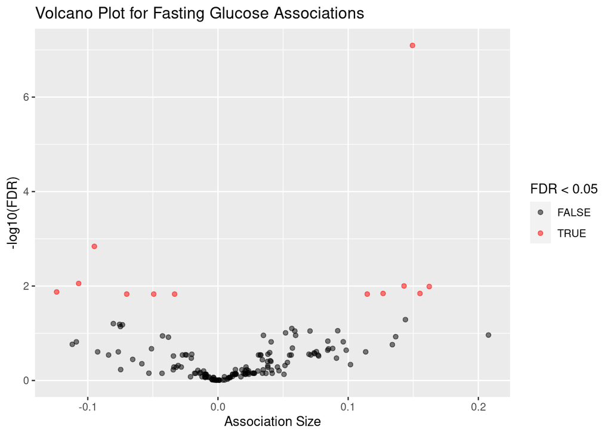

```r
ggplot(LBXGLU_train_summary, aes(x = Estimate, y = -log10(FDR))) +
  geom_point(aes(color = FDR < 0.05), alpha = 0.5) +  # Color points based on significance threshold
  scale_color_manual(values = c("TRUE" = "red", "FALSE" = "black")) +
  labs(title = "Volcano Plot for Fasting Glucose Associations",
       x = "Association Size",
       y = "-log10(FDR)")
```

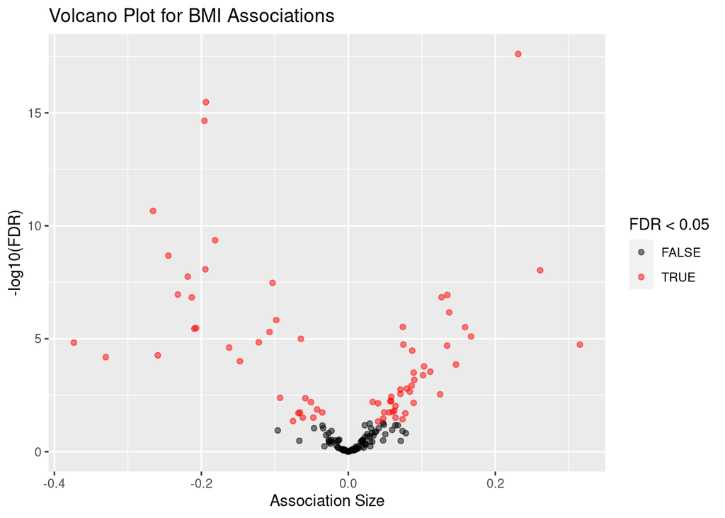

```r
ggplot(BMI_train_summary, aes(x = Estimate, y = -log10(FDR))) +
  geom_point(aes(color = FDR < 0.05), alpha = 0.5) +  # Color points based on significance threshold
  scale_color_manual(values = c("TRUE" = "red", "FALSE" = "black")) +
  labs(title = "Volcano Plot for BMI Associations",
       x = "Association Size",
       y = "-log10(FDR)")
```

4. Filter “replicated” findings using the following heuristic: FDR significance of 0.05 in the training dataset, p-value < 0.05 in the testing dataset, and concordant directionality of associations (e.g., both associations are >0 OR both are <0). Provide your answer in the form of a table with the estimate of the “replicated” findings in the train, test, the FDR from the training data and pvalue from the test cohort data. (3)

```r
LBXGLU_train_summary$Direction <- sign(LBXGLU_train_summary$Estimate)
LBXGLU_test_summary$Direction <- sign(LBXGLU_test_summary$Estimate)

LBXGLU_merged <- merge(LBXGLU_train_summary, LBXGLU_test_summary, by = "ExposureID", suffixes = c("_train", "_test"))

replicated_LBXGLU <- LBXGLU_merged %>%
  filter(FDR_train < 0.05, P_Value_test < 0.05, Direction_train == Direction_test)

replicated_LBXGLU <- replicated_LBXGLU %>%
  select(ExposureID, Estimate_train, Estimate_test, FDR_train, P_Value_test)

print(replicated_LBXGLU)
```

```
##   ExposureID Estimate_train Estimate_test    FDR_train P_Value_test
## 1     LBXBEC    -0.10698716   -0.11954367 8.825052e-03 1.035858e-07
## 2     LBXBHC     0.16229864    0.13485096 1.025444e-02 1.544208e-03
## 3     LBXCBC    -0.09494002   -0.11682838 1.447608e-03 1.307889e-07
## 4     LBXCRY    -0.07007805   -0.03685281 1.480267e-02 3.776902e-02
## 5     LBXGTC     0.14940896    0.13451533 8.057415e-08 2.093686e-08
## 6     LBXIRN    -0.04933975   -0.05874742 1.480267e-02 6.845531e-03
## 7     LBXPDT     0.14289761    0.10701849 9.963996e-03 4.476741e-02
## 8    LBXPFDO    -0.03329323   -0.05357508 1.480267e-02 2.037301e-02
## 9     LBXVID    -0.12391704   -0.10849670 1.334073e-02 1.744190e-07
```

```r
BMI_train_summary$Direction <- sign(BMI_train_summary$Estimate)
BMI_test_summary$Direction <- sign(BMI_test_summary$Estimate)

BMI_merged <- merge(BMI_train_summary, BMI_test_summary, by = "ExposureID", suffixes = c("_train", "_test"))

replicated_BMI <- BMI_merged %>%
  filter(FDR_train < 0.05, P_Value_test < 0.05, Direction_train == Direction_test)

replicated_BMI <- replicated_BMI %>%
  select(ExposureID, Estimate_train, Estimate_test, FDR_train, P_Value_test)

print(replicated_BMI)
```

```
##    ExposureID Estimate_train Estimate_test    FDR_train P_Value_test
## 1      LBD199    -0.33010454   -0.32084025 6.499274e-05 8.867554e-06
## 2      LBX074     0.07385707    0.12426190 3.657064e-02 4.413574e-02
## 3      LBX099     0.07963111    0.10958538 1.606144e-03 1.352899e-02
## 4      LBX105     0.05567781    0.14909468 1.820425e-02 3.527783e-03
## 5      LBX118     0.11158087    0.14046734 2.856712e-04 1.034242e-02
## 6      LBX146    -0.06585106   -0.13160751 1.820425e-02 4.666279e-03
## 7      LBX153    -0.07525148   -0.12174727 4.379409e-02 1.214644e-02
## 8      LBX156    -0.12185533   -0.16362952 1.434400e-05 1.578754e-03
## 9      LBX170    -0.16225105   -0.23479979 2.444221e-05 1.457924e-04
## 10     LBX178    -0.06790041   -0.27770939 1.970985e-02 3.773761e-06
## 11     LBX180    -0.20723657   -0.33736048 3.326261e-06 3.816180e-06
## 12     LBX187    -0.09283681   -0.19411793 4.074805e-03 2.581736e-04
## 13     LBX194    -0.37348782   -0.31417257 1.483794e-05 3.046144e-06
## 14     LBX196    -0.25926778   -0.24635865 5.378284e-05 7.689190e-05
```

[output cut: 45 more lines]

5. Environmental exposures are highly correlated with one another and they can change over time. Therefore, exposures could be subject to many biases. Describe a type of bias (e.g., selection, sampling, or other) that can influence your findings and give an example.(2)
- There can be selection biases in variables such as vitamin A, vitamin B and vitamin E in blood samples. For example, if most of the participants in this study do not consume much vegetables or fruits in their daily diet, then these mineral levels in blood would expect to be lower. This type of bias occurs when the participants included in the study are not representative for the entire population, leading to ungeneralizable results
6. BMI is a risk factor for diabetes: individuals with higher BMI are at risk for future type 2 diabetes. In this study, we found factors associated with both. For exposures that are found in both BMI and type 2 diabetes - do you think exposure is influencing both traits independently, or via BMI, or neither? Explain why. Optional: Write down a possible linear regression model to test your hypothesis and interpret the finding. (3)
- Linear model:
1. T2D ~ Exposure + BMI + Covariates
2. T2D ~ Exposure + Covariates
- In my opinion, the exposure influences type 2 diabetes primarily via its effect on BMI, indicating BMI is the mediator. Within the suggested linear models, we are adjusting the effects by BMI to confirm our idea. If the first model is significantly reduced compared to the second model, it suggests that BMI mediates the relationship between the exposure and type 2 diabetes. Otherwise, if the first model has no difference with the second model, then the effects by exposures are indepedent of BMI.

# (Optional) Parallelization?

The compute available to you includes 16GB of RAM and 4CPU. If time is available, consider utilizing the CPUs to “paralleize” your pipeline in part B, using packages such as “future” and “furrr” (https://furrr.futureverse.org/)